BIF-7900 · Bioinformatique I · Statistiques avec R

# Solutionnaire du TP1

# À votre tour

## 0. Importer les données

```r
library(tidyverse)
library(car)
manchots <- read_tsv("/home/public/stat/penguins.tsv")
```

```r
nrow(manchots)
```

```
#> [1] 344
```

```r
count(manchots, sex)
```

```
#> # A tibble: 3 × 2
#>   sex        n
#>   <chr>  <int>
#> 1 female   165
#> 2 male     168
#> 3 <NA>      11
```

344 manchots, dont 11 de sexe inconnu (`NA`).

## 1. Décrire par espèce et par sexe

```r
manchots |>
  summarise(n = n(),
            moyenne = mean(body_mass, na.rm = TRUE),
            mediane = median(body_mass, na.rm = TRUE),
            ecart_type = sd(body_mass, na.rm = TRUE),
            .by = c(species, sex))
```

```
#> # A tibble: 8 × 6
#>   species   sex        n moyenne mediane ecart_type
#>   <chr>     <chr>  <int>   <dbl>   <dbl>      <dbl>
#> 1 Adelie    male      73   4043.   4000        347.
#> 2 Adelie    female    73   3369.   3400        269.
#> 3 Adelie    <NA>       6   3540    3475        477.
#> 4 Gentoo    female    58   4680.   4700        282.
#> 5 Gentoo    male      61   5485.   5500        313.
#> 6 Gentoo    <NA>       5   4588.   4688.       338.
#> 7 Chinstrap female    34   3527.   3550        285.
#> 8 Chinstrap male      34   3939.   3950        362.
```

Dans chaque espèce, les mâles sont plus lourds. Moyenne et médiane sont proches : pas d’asymétrie marquée. Les lignes `NA` regroupent les manchots de sexe inconnu.

## 2. Visualiser la normalité

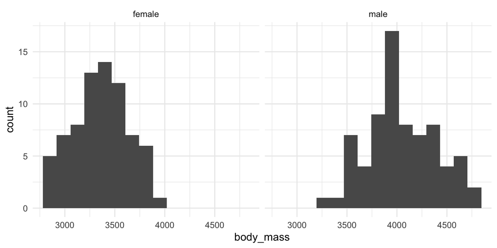

```r
adelie <- manchots |> filter(species == "Adelie", !is.na(sex))

ggplot(adelie, aes(body_mass)) +
  geom_histogram(bins = 15) +
  facet_wrap(~ sex)
```

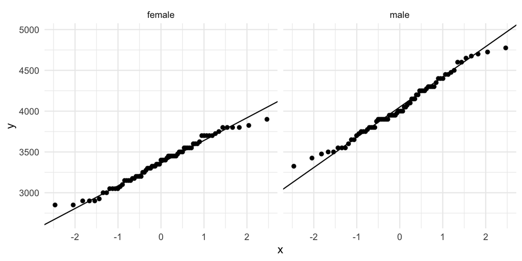

```r
ggplot(adelie, aes(sample = body_mass)) +
  stat_qq() + stat_qq_line() +
  facet_wrap(~ sex)
```

Les points suivent la droite dans les deux groupes, à part de légers écarts aux extrémités : la normalité est plausible.

## 3. Shapiro-Wilk et Levene

```r
adelie |> summarise(p_shapiro = shapiro.test(body_mass)$p.value, .by = sex)
```

```
#> # A tibble: 2 × 2
#>   sex    p_shapiro
#>   <chr>      <dbl>
#> 1 male       0.416
#> 2 female     0.199
```

```r
leveneTest(body_mass ~ factor(sex), data = adelie)
```

```
#> Levene's Test for Homogeneity of Variance (center = median)
#>        Df F value  Pr(>F)
#> group   1  3.8664 0.05118 .
#>       144
#> ---
#> Signif. codes:  0 '***' 0.001 '**' 0.01 '*' 0.05 '.' 0.1 ' ' 1
```

Shapiro-Wilk : p > 0.05 dans les deux groupes, on ne rejette pas la normalité (avec 73 manchots par groupe, le t-test serait de toute façon robuste). Levene : p ≈ 0.05, à la limite. Le t-test de Welch, utilisé par défaut, ne suppose pas l’égalité des variances : il convient.

## 4. Le t-test

```r
t.test(body_mass ~ sex, data = adelie)
```

```
#>
#>  Welch Two Sample t-test
#>
#> data:  body_mass by sex
#> t = -13.126, df = 135.69, p-value < 2.2e-16
#> alternative hypothesis: true difference in means between group female and group male is not equal to 0
#> 95 percent confidence interval:
#>  -776.3012 -573.0139
#> sample estimates:
#> mean in group female   mean in group male
#>             3368.836             4043.493
```

La sortie compare `female` − `male` (ordre alphabétique des niveaux), d’où les valeurs négatives de l’intervalle.

## 5. Wilcoxon

```r
wilcox.test(body_mass ~ sex, data = adelie, exact = FALSE)
```

```
#>
#>  Wilcoxon rank sum test with continuity correction
#>
#> data:  body_mass by sex
#> W = 310.5, p-value < 2.2e-16
#> alternative hypothesis: true location shift is not equal to 0
```

Même conclusion : la différence est nette, quel que soit le test. Quand les conditions du t-test sont réunies, les deux tests concordent ; c’est surtout avec de petits effectifs ou des valeurs aberrantes qu’ils peuvent diverger.

## 6. Données appariées : `sleep`

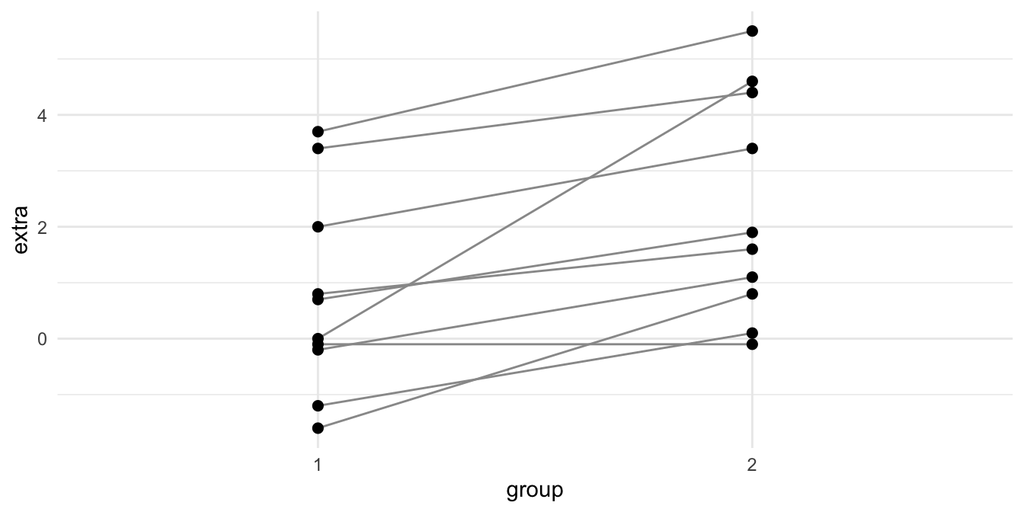

```r
ggplot(sleep, aes(group, extra)) +
  geom_line(aes(group = ID), colour = "grey60") +
  geom_point(size = 2)
```

```r
# indépendant : faux ici
t.test(extra ~ group, data = sleep)$p.value
```

```
#> [1] 0.07939414
```

```r
# apparié : on aligne d'abord les deux mesures de chaque patient
sommeil <- sleep |>
  pivot_wider(names_from = group, values_from = extra, names_prefix = "som_")
sommeil
```

```
#> # A tibble: 10 × 3
#>    ID    som_1 som_2
#>    <fct> <dbl> <dbl>
#>  1 1       0.7   1.9
#>  2 2      -1.6   0.8
#>  3 3      -0.2   1.1
#>  4 4      -1.2   0.1
#>  5 5      -0.1  -0.1
#>  6 6       3.4   4.4
#>  7 7       3.7   5.5
#>  8 8       0.8   1.6
#>  9 9       0     4.6
#> 10 10      2     3.4
```

```r
t.test(sommeil$som_2, sommeil$som_1, paired = TRUE)
```

```
#>
#>  Paired t-test
#>
#> data:  sommeil$som_2 and sommeil$som_1
#> t = 4.0621, df = 9, p-value = 0.002833
#> alternative hypothesis: true mean difference is not equal to 0
#> 95 percent confidence interval:
#>  0.7001142 2.4598858
#> sample estimates:
#> mean difference
#>            1.58
```

Le test **apparié** est le bon : chaque patient a reçu les deux somnifères. Il teste les 10 différences individuelles (moyenne 1.58 h), et la variabilité entre patients, très grande, disparaît. Le test indépendant compare deux nuages de points où cette variabilité noie l’effet : p = 0.08 au lieu de 0.003.

# Et si… ?

## 1. Oublier les sexes inconnus

```r
t.test(body_mass ~ sex, data = filter(manchots, species == "Adelie"))$p.value
```

```
#> [1] 6.40232e-26
```

```r
filter(manchots, species == "Adelie") |> count(sex)
```

```
#> # A tibble: 3 × 2
#>   sex        n
#>   <chr>  <int>
#> 1 female    73
#> 2 male      73
#> 3 <NA>       6
```

Le résultat est **identique** : la formule `body_mass ~ sex` écarte les lignes où `sex` vaut `NA`, **sans aucun message**. Le test porte sur 146 manchots et non 152. Ici sans conséquence, mais il faut toujours savoir **combien d’observations** un test a réellement utilisées.

## 2. Trois espèces dans `t.test()`

```r
t.test(body_mass ~ species, data = manchots)
```

```
#> Error in t.test.formula(body_mass ~ species, data = manchots): grouping factor must have exactly 2 levels
```

`grouping factor must have exactly 2 levels` : un t-test compare **deux** groupes. Pour trois espèces, c’est une ANOVA (TP2).

## 3. Adélie contre Chinstrap

```r
t.test(body_mass ~ species, data = filter(manchots, species %in% c("Adelie", "Chinstrap")))
```

```
#>
#>  Welch Two Sample t-test
#>
#> data:  body_mass by species
#> t = -0.54309, df = 152.45, p-value = 0.5879
#> alternative hypothesis: true difference in means between group Adelie and group Chinstrap is not equal to 0
#> 95 percent confidence interval:
#>  -150.38481   85.53284
#> sample estimates:
#>    mean in group Adelie mean in group Chinstrap
#>                3700.662                3733.088
```

p = 0.59 : on **ne rejette pas** H0. Mais on ne peut pas conclure que les masses sont **égales** : l’absence de preuve n’est pas la preuve de l’absence. L’intervalle de confiance dit ce qu’on sait vraiment : la différence (Adélie − Chinstrap) est quelque part entre −150 et +86 g. Des différences de l’ordre de 100 g restent compatibles avec les données.

## 4. Changer l’ordre des niveaux

```r
adelie |>
  mutate(sex = factor(sex, levels = c("male", "female"))) |>
  t.test(body_mass ~ sex, data = _)
```

```
#>
#>  Welch Two Sample t-test
#>
#> data:  body_mass by sex
#> t = 13.126, df = 135.69, p-value < 2.2e-16
#> alternative hypothesis: true difference in means between group male and group female is not equal to 0
#> 95 percent confidence interval:
#>  573.0139 776.3012
#> sample estimates:
#>   mean in group male mean in group female
#>             4043.493             3368.836
```

La différence est maintenant **mâles − femelles** : la statistique t et l’intervalle de confiance changent de **signe**. La p-value, elle, ne change pas. C’est le même mécanisme que le niveau de référence dans `lm()` et DESeq2 (TP2 et TP3) : **le premier niveau sert de référence**, et il faut le savoir pour lire le signe d’un effet.

## 5. Des paires dans le désordre

```r
set.seed(1)
t.test(sample(sommeil$som_2), sommeil$som_1, paired = TRUE)$p.value
```

```
#> [1] 0.130873
```

**Aucun message** : R apparie la 1<sup>re</sup> valeur avec la 1<sup>re</sup>, la 2<sup>e</sup> avec la 2<sup>e</sup>… sans savoir à quel patient elles appartiennent. Les différences calculées n’ont plus de sens, et la p-value passe de 0.003 à une valeur non significative. C’est pourquoi on aligne les paires avec `pivot_wider()` sur la colonne `ID`, plutôt que d’extraire deux vecteurs séparément.